# Data Analysis with R—Problem Set 5

Load the packages

```r
library(ggplot2)
data(diamonds)
?diamonds
```

Get the dimension and summary

```r
dim(diamonds)
```

```
## [1] 53940    10
```

```r
summary(diamonds)
```

```
##      carat               cut        color        clarity
##  Min.   :0.2000   Fair     : 1610   D: 6775   SI1    :13065
##  1st Qu.:0.4000   Good     : 4906   E: 9797   VS2    :12258
##  Median :0.7000   Very Good:12082   F: 9542   SI2    : 9194
##  Mean   :0.7979   Premium  :13791   G:11292   VS1    : 8171
##  3rd Qu.:1.0400   Ideal    :21551   H: 8304   VVS2   : 5066
##  Max.   :5.0100                     I: 5422   VVS1   : 3655
##                                     J: 2808   (Other): 2531
##      depth           table           price             x
##  Min.   :43.00   Min.   :43.00   Min.   :  326   Min.   : 0.000
##  1st Qu.:61.00   1st Qu.:56.00   1st Qu.:  950   1st Qu.: 4.710
##  Median :61.80   Median :57.00   Median : 2401   Median : 5.700
##  Mean   :61.75   Mean   :57.46   Mean   : 3933   Mean   : 5.731
##  3rd Qu.:62.50   3rd Qu.:59.00   3rd Qu.: 5324   3rd Qu.: 6.540
##  Max.   :79.00   Max.   :95.00   Max.   :18823   Max.   :10.740
##
##        y                z
##  Min.   : 0.000   Min.   : 0.000
##  1st Qu.: 4.720   1st Qu.: 2.910
##  Median : 5.710   Median : 3.530
##  Mean   : 5.735   Mean   : 3.539
##  3rd Qu.: 6.540   3rd Qu.: 4.040
##  Max.   :58.900   Max.   :31.800
##
```

```r
summary(diamonds$color)
```

```
##     D     E     F     G     H     I     J
##  6775  9797  9542 11292  8304  5422  2808
```

```
## stat_bin: binwidth defaulted to range/30. Use 'binwidth = x' to adjust this.
```

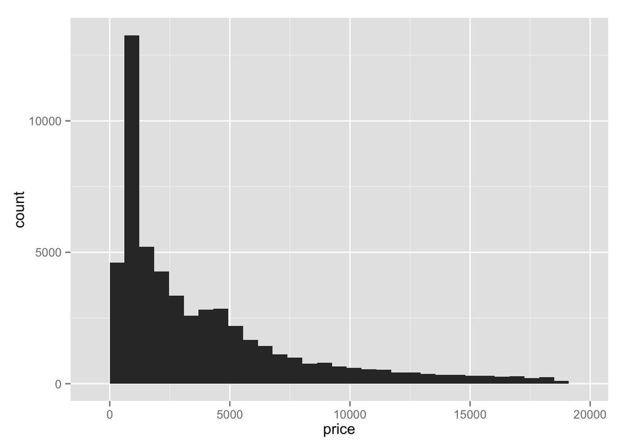

```r
qplot(price, data = diamonds)
```

```r
mean(diamonds$price)
```

```
## [1] 3932.8
```

```r
median(diamonds$price)
```

```
## [1] 2401
```

# Q1

[output not shown]

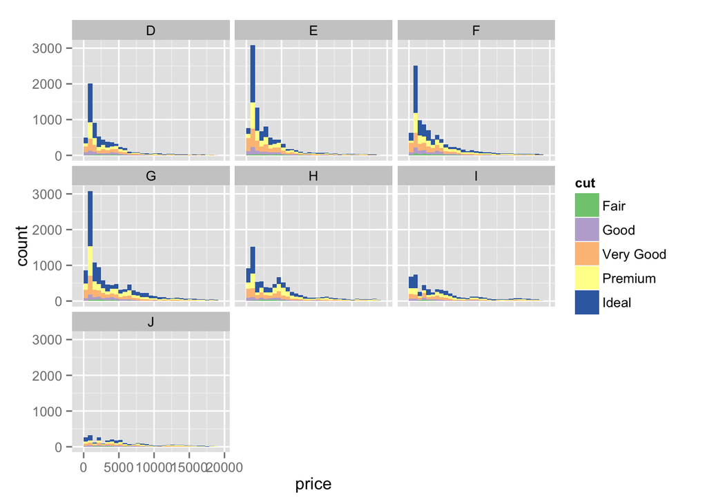

```r
ggplot(aes(price,fill=cut),data=diamonds)+geom_bar()+facet_wrap(~color)+scale_fill_brewer(type = 'qual')
```

### Q2: Create a scatterplot of diamond price vs. table and color the points by the cut of the diamond.

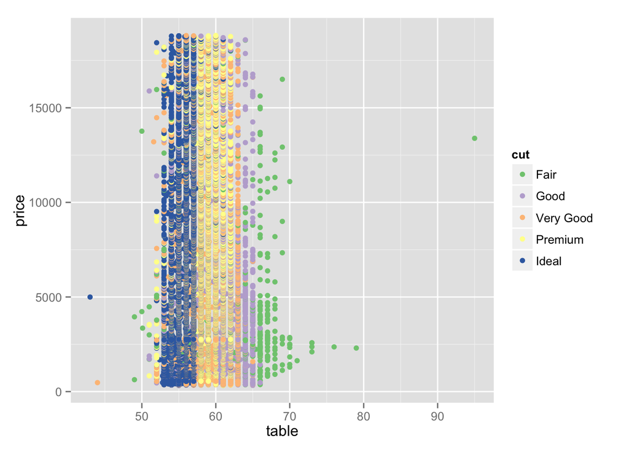

```r
ggplot(aes(x=table,y=price,color=cut),data=diamonds)+
  geom_point(aes(color=cut))+scale_color_brewer(type='qual')
```

Note: in Q1, we use `scale_fill_brewer` to set the theme of color, but in Q2 we use `scale_color_brewer`.

### Q4:

Create a scatterplot of diamond price vs. volume (x * y * z) and color the points by the clarity of diamonds. Use scale on the y-axis to take the log10 of price. You should also omit the top 1% of diamond volumes from the plot.

Note: Volume is a very rough approximation of a diamond’s actual volume.

Note: In the link, a color palette of type ‘div’ was used to color the scatterplot using `scale_color_brewer(type = 'div')`

Note: `quantile(diamonds$vol,0.99)` is different from `0.99*max(diamonds$vol)`. The former takes the last 99% of the rank, while the later one takes 0.99 of the maximum value.

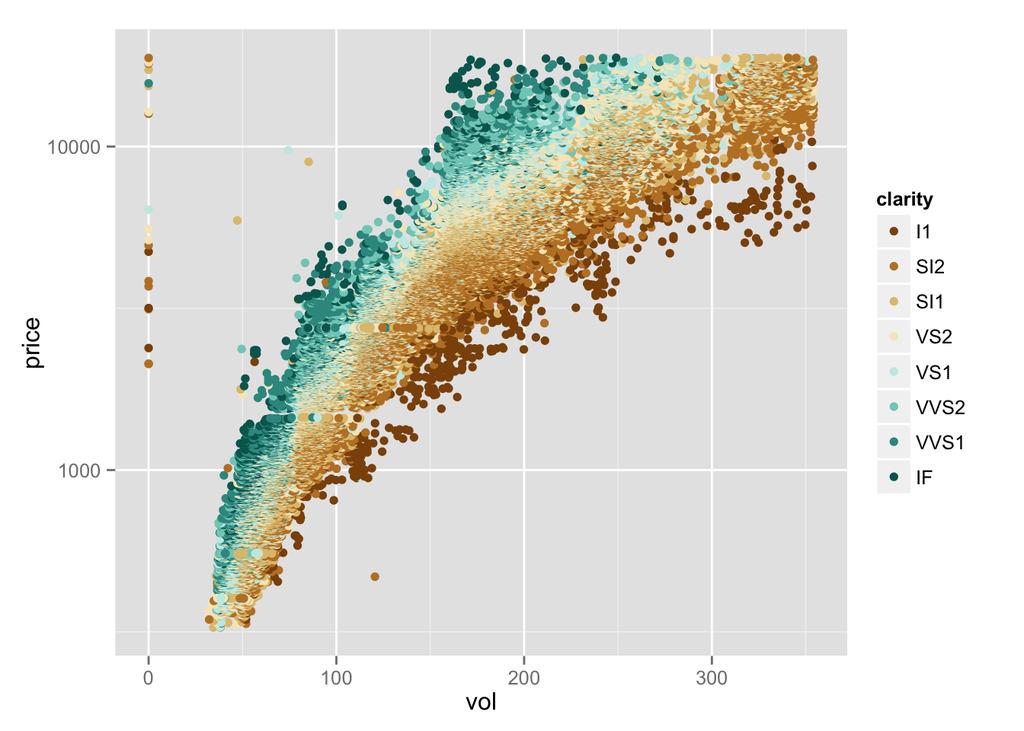

```r
diamonds$vol=with(diamonds,x*y*z)
s_diamonds=subset(diamonds,vol<quantile(diamonds$vol,0.99))
ggplot(aes(x=vol,y=price,color=clarity),data=s_diamonds)+geom_point()+scale_y_log10()+scale_color_brewer(type = 'div')
```

### Extra: Density plot

examples from ggplot book p.69

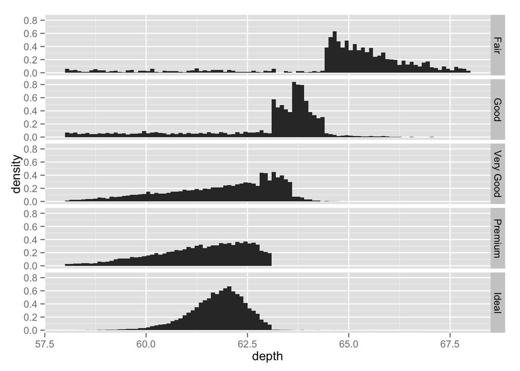

```r
depth_dist<-ggplot(diamonds,aes(depth))+xlim(58,68)
depth_dist+geom_histogram(aes(y=..density..),binwidth=0.1)+facet_grid(cut~.)
```

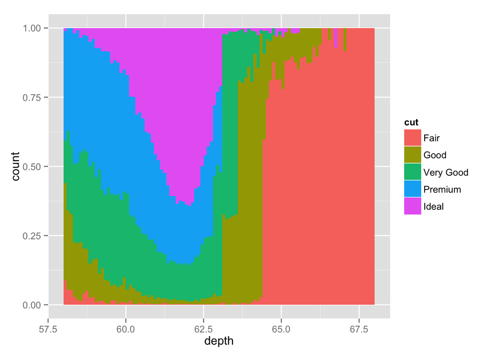

```r
depth_dist+geom_histogram(aes(fill=cut),binwidth=0.1,position="fill")
```

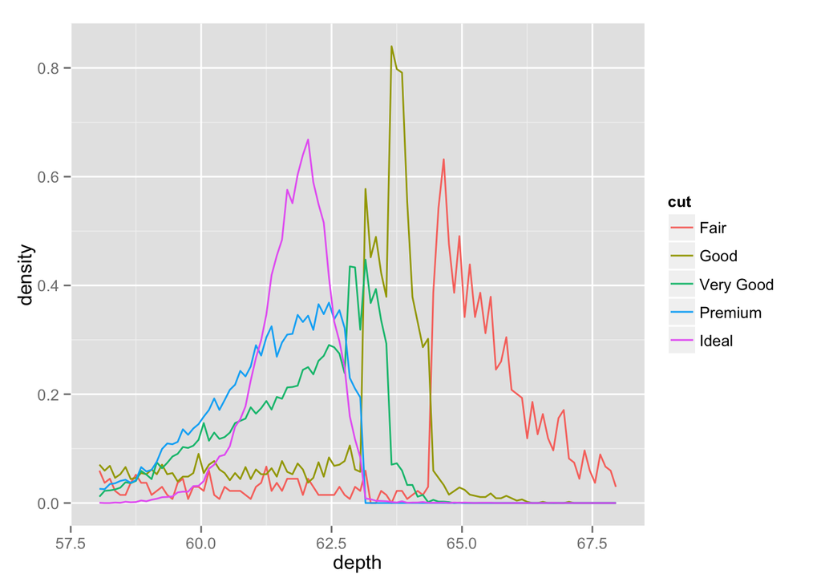

```r
depth_dist+geom_freqpoly(aes(y=..density..,color=cut),binwidth=0.1)
```